# Analysis of Weekday Effects

# Load support functions and libraries

```r
# Load libraries
library("httr")
library("jsonlite")
library("quantmod")
library("mgcv")
source("./support_functions.R")
# Read the saved data
btc.data <- read.csv("./BTC_historical_march_10.csv")
eth.data <- read.csv("./ETH_historical_march_10.csv")
# Create some support functions
btc.data <- as.data.frame(btc.data)
getDate <- function(x){
  date.stamp <- as.Date(strsplit(as.character(x)," ")[[1]][1], origin="1970-01-01")
  return(date.stamp)
}
getHour <- function(x){
  hour <- as.numeric(strsplit(strsplit(as.character(x)," ")[[1]][2],":")[[1]][1])
  return(hour)
}
getWeekday <- function(x){
  weekday <- weekdays(as.Date(as.character(x), origin="1970-01-01"))
  return(weekday)
}
```

# Analysis for BTC

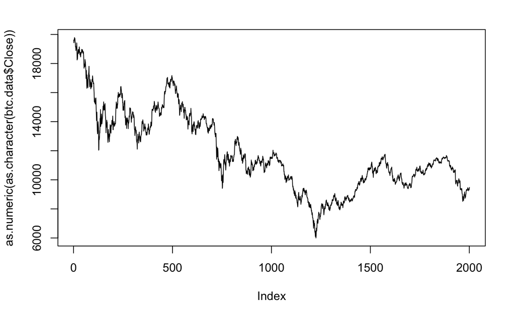

```r
btc.data <- as.data.frame(btc.data)
btc.data$date.stamp <- as.Date(unlist(lapply(as.character(btc.data$Time.Stamp), getDate)), origin="1970-01-01")
btc.data$hour <- unlist(lapply(btc.data$`Time.Stamp`, getHour))
btc.data$weekday <- unlist(lapply(btc.data$`Time.Stamp`, getWeekday))
plot(as.numeric(as.character(btc.data$Close)), type="lines")
```

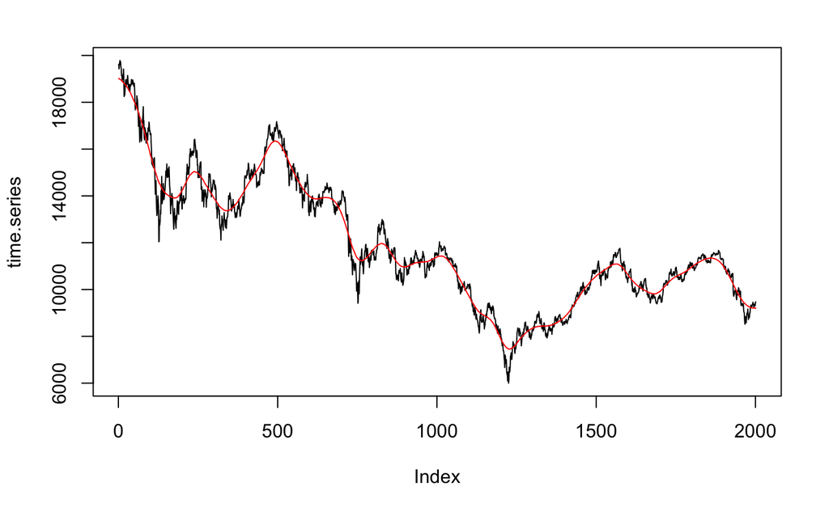

```r
btc.data$price.detrended <- as.numeric(as.character(btc.data$Close))/probabilisticSmoothing(as.numeric(as.character(btc.data$Close)), trials = 2000, lag.u = 0, lag.sd = 24) - 1
```

```r
btc.data$weekday <- as.factor(btc.data$weekday)
summary(lm(price.detrended ~ weekday, data=btc.data))
```

```
Call:
lm(formula = price.detrended ~ weekday, data = btc.data)

Residuals:
      Min        1Q    Median        3Q       Max
-0.192447 -0.020987  0.002619  0.023073  0.093830

Coefficients:
                  Estimate Std. Error t value Pr(>|t|)
(Intercept)      -0.016382   0.002079  -7.879 5.36e-15 ***
weekdayMonday     0.015841   0.002940   5.388 7.99e-08 ***
weekdaySaturday   0.031677   0.002959  10.707  < 2e-16 ***
weekdaySunday     0.017485   0.002961   5.905 4.15e-09 ***
weekdayThursday   0.016665   0.002940   5.668 1.66e-08 ***
weekdayTuesday    0.013340   0.002940   4.537 6.05e-06 ***
weekdayWednesday  0.015250   0.002940   5.186 2.36e-07 ***
---
Signif. codes:  0 '***' 0.001 '**' 0.01 '*' 0.05 '.' 0.1 ' ' 1

Residual standard error: 0.03528 on 1994 degrees of freedom
Multiple R-squared:  0.05538,   Adjusted R-squared:  0.05254
F-statistic: 19.48 on 6 and 1994 DF,  p-value: < 2.2e-16
```

# Now aggregate onto the daily level and check the effect

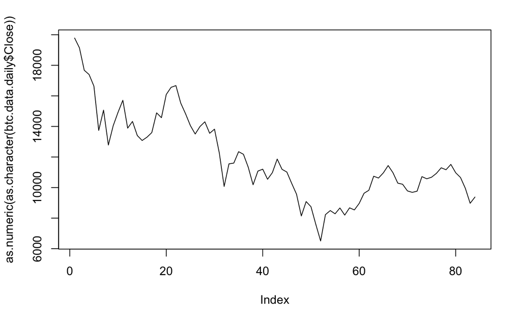

```r
btc.data.daily <- subset(btc.data, btc.data$hour == "12")
plot(as.numeric(as.character(btc.data.daily$Close)), type="lines")
```

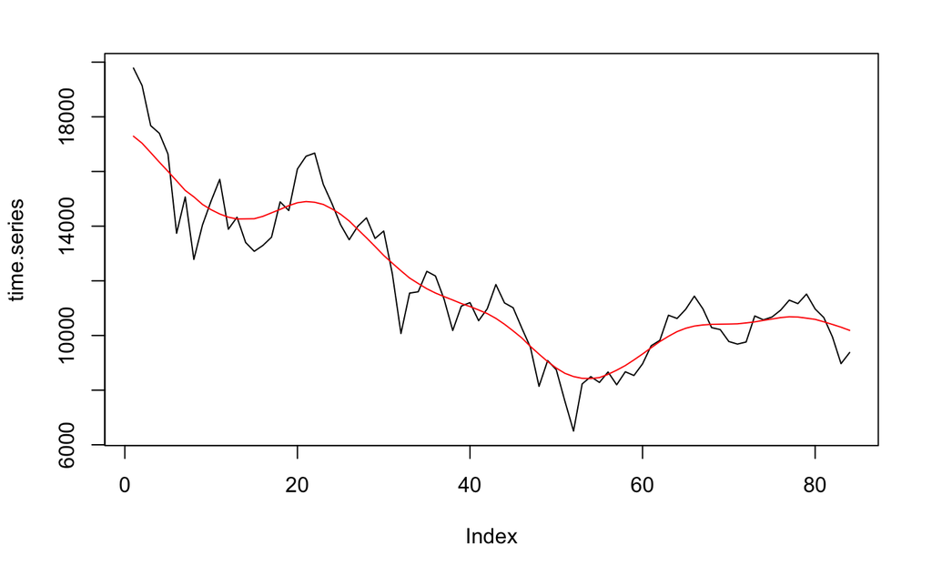

```r
btc.data.daily$price.detrended <- as.numeric(as.character(btc.data.daily$Close))/probabilisticSmoothing(as.numeric(as.character(btc.data.daily$Close)), trials = 2000, lag.u = 0, lag.sd = 4) - 1
```

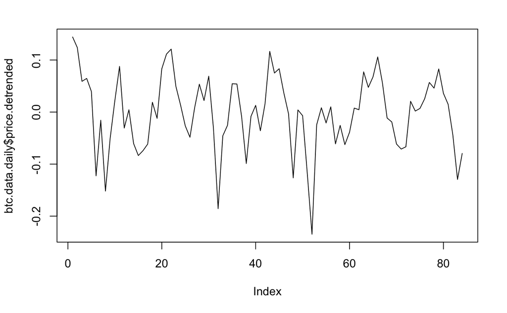

```r
btc.data.daily$weekday <- as.factor(btc.data.daily$weekday)
# Plot the detrended value
plot(btc.data.daily$price.detrended, type="lines")
```

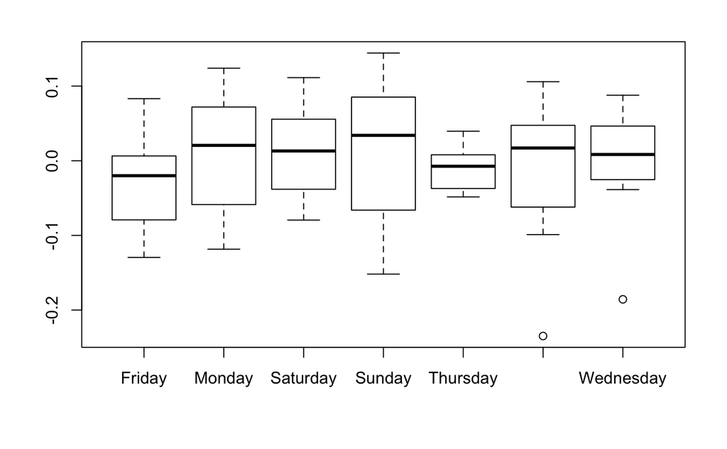

```r
# Plot the Weekday vs the Price
plot(btc.data.daily$weekday, btc.data.daily$price.detrended)
```

```r
# Regression of day vs Price
lm.fit <- lm(price.detrended ~ weekday, data=btc.data.daily)
```

The plot above shows the estimated effect of each weekday, after aggregating. As expected Saturday, Sunday and Monday appear to have the strongest effect. The effects are not strongly significant to a scientific level, but there is likely a positive effect based on the sample. This can be seen in the table below:

```r
summary(lm.fit)
```

```
Call:
lm(formula = price.detrended ~ weekday, data = btc.data.daily)

Residuals:
      Min        1Q    Median        3Q       Max
-0.222395 -0.036573  0.007934  0.041159  0.129539

Coefficients:
                 Estimate Std. Error t value Pr(>|t|)
(Intercept)      -0.02949    0.02091  -1.410    0.163
weekdayMonday     0.03981    0.02958   1.346    0.182
weekdaySaturday   0.04337    0.02958   1.466    0.147
weekdaySunday     0.04421    0.02958   1.495    0.139
weekdayThursday   0.01950    0.02958   0.659    0.512
weekdayTuesday    0.01712    0.02958   0.579    0.564
weekdayWednesday  0.02930    0.02958   0.991    0.325

Residual standard error: 0.07245 on 77 degrees of freedom
Multiple R-squared:  0.04573,   Adjusted R-squared:  -0.02863
F-statistic: 0.6149 on 6 and 77 DF,  p-value: 0.7177
```

# The following analysis will check for combination of day and time effects

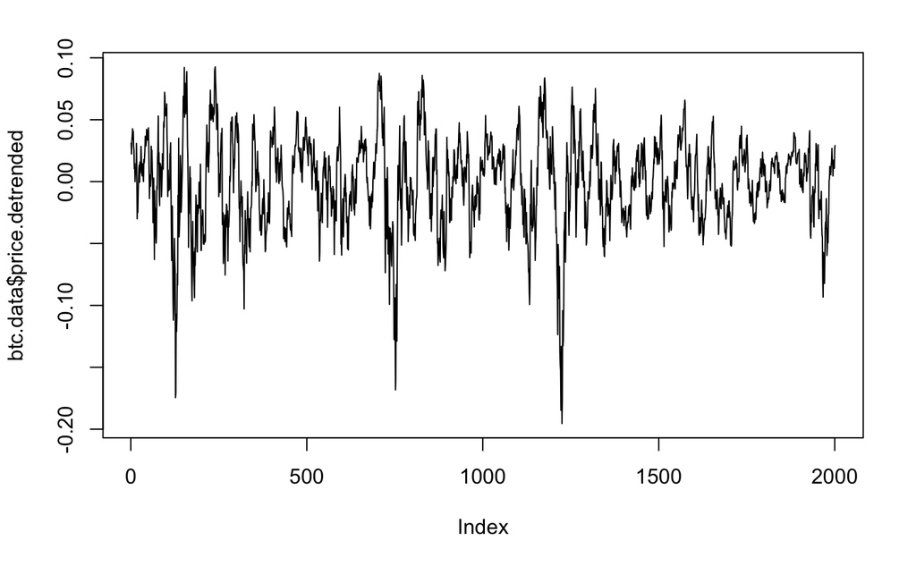

```r
# Now look at the day/time combination
btc.data$weekday.hour <- paste(btc.data$weekday,"_",btc.data$hour, sep="")
first.value <- btc.data[1,'weekday.hour']
counter <- 1
btc.data$weekday.hour.num <- NA
for (i in 1:nrow(btc.data)){
  if (btc.data[i,'weekday.hour'] == first.value){
    counter <- 1
    btc.data[i,'weekday.hour.num'] <- counter
  } else {
    btc.data[i,'weekday.hour.num'] <- counter
  }
  counter <- counter + 1
}
btc.data$weekday.hour.num <- as.numeric(as.factor(btc.data$weekday.hour))
cyclical.vars <- cyclicalTransformation(btc.data$weekday.hour.num, 168)
btc.data <- cbind(btc.data, cyclical.vars)
# Linear model fit
lm.fit <- lm(price.detrended ~ x + y, data=btc.data)
plot(btc.data$price.detrended, type="lines")
```

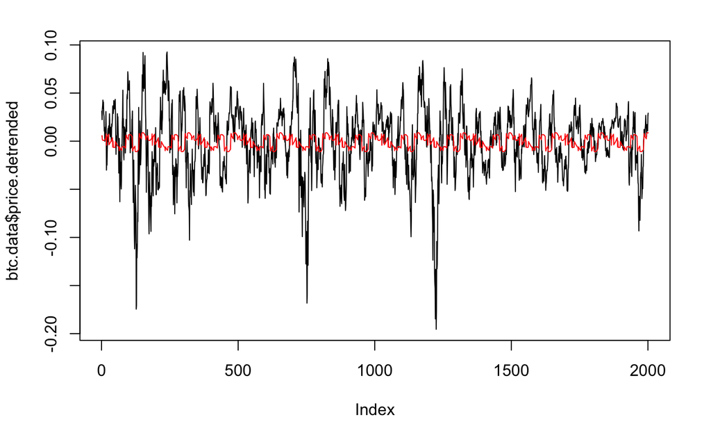

```r
# Non linear fit
gam.fit <- mgcv::gam(price.detrended ~ s(x, k=4) + s(y, k=4), data=btc.data, family="gaussian")
{plot(btc.data$price.detrended, type="lines")
lines(predict(gam.fit), col="red")}
```

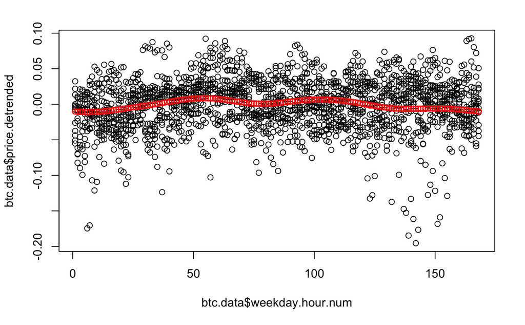

```r
{plot(btc.data$weekday.hour.num, btc.data$price.detrended)
points(btc.data$weekday.hour.num, predict(gam.fit), col="red")}
```

The plot above shows the estimated fit based on the time of day and weekday combination. You can see that there is a lot of noise, and as such there is unlikely to be a strong pattern based on time of day. However we can check this as we receive more data.

# Analysis of ETH

```r
eth.data <- as.data.frame(eth.data)
eth.data$date.stamp <- as.Date(unlist(lapply(eth.data$`Time.Stamp`, getDate)), origin="1970-01-01")
eth.data$hour <- unlist(lapply(eth.data$`Time.Stamp`, getHour))
eth.data$weekday <- unlist(lapply(eth.data$`Time.Stamp`, getWeekday))
plot(as.numeric(as.character(eth.data$Close)), type="lines")
eth.data$price.detrended <- as.numeric(as.character(eth.data$Close))/probabilisticSmoothing(as.numeric(as.character(eth.data$Close)), trials = 2000, lag.u = 0, lag.sd = 24) - 1
```

[output not shown]

# Aggregate onto a daily level

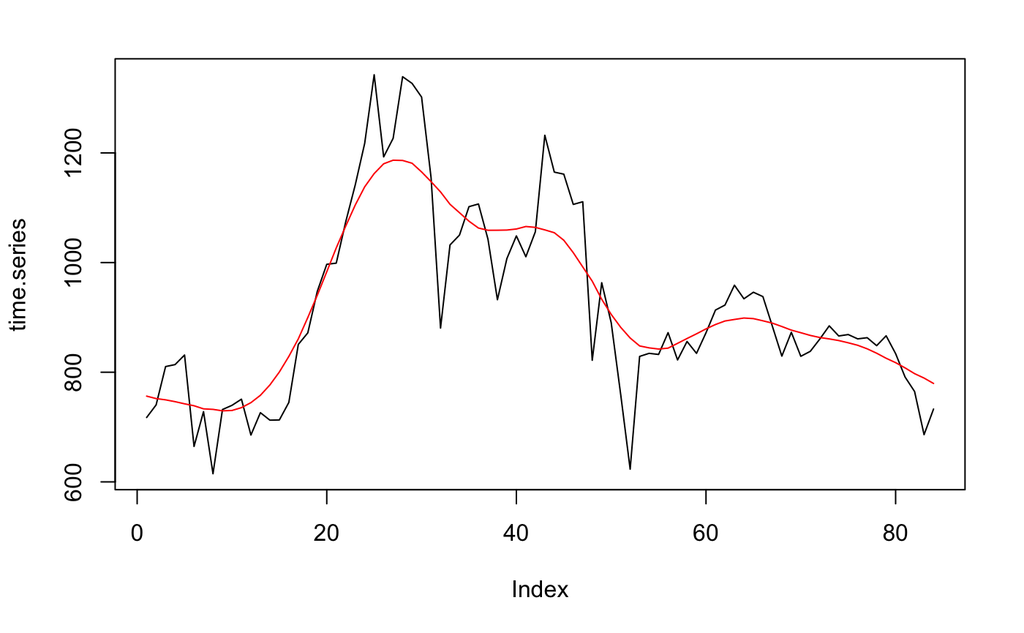

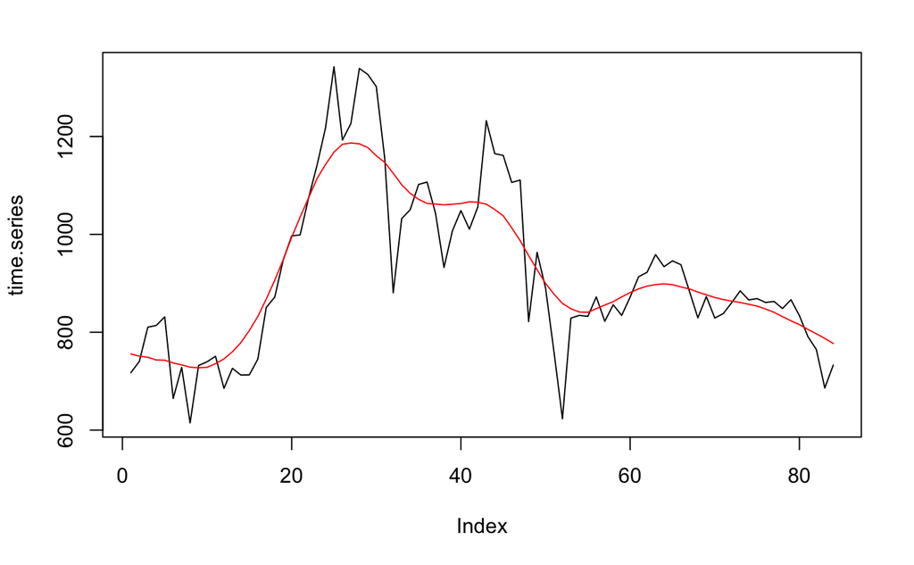

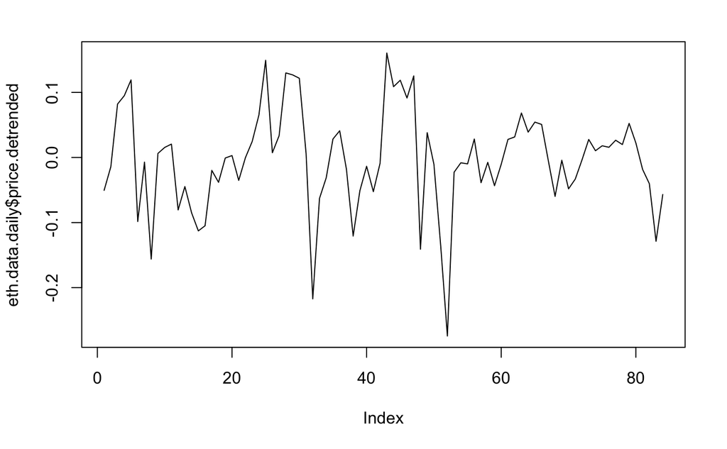

```r
eth.data.daily$price.detrended <- as.numeric(as.character(eth.data.daily$Close))/probabilisticSmoothing(as.numeric(as.character(eth.data.daily$Close)), trials = 2000, lag.u = 0, lag.sd = 4) - 1
eth.data.daily$price.detrended <- as.numeric(as.character(eth.data.daily$Close))/probabilisticSmoothing(as.numeric(as.character(eth.data.daily$Close)), trials = 2000, lag.u = 0, lag.sd = 4) - 1

eth.data.daily$weekday <- as.factor(eth.data.daily$weekday)
# Plot the detrended value
plot(eth.data.daily$price.detrended, type="lines")
```

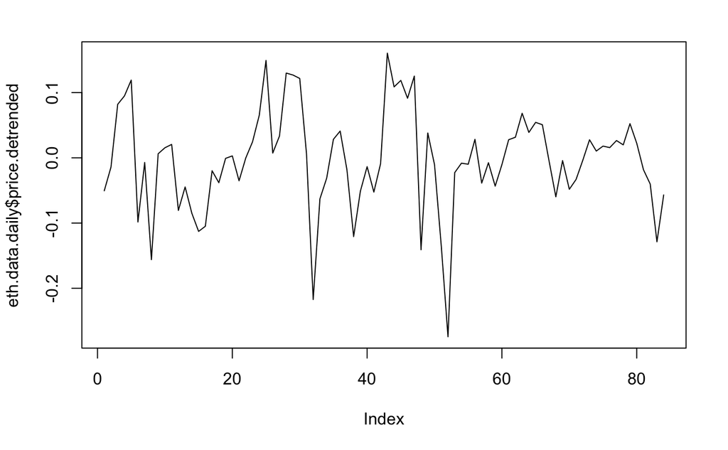

```r
# Plot the detrended value
plot(eth.data.daily$price.detrended, type="lines")
```

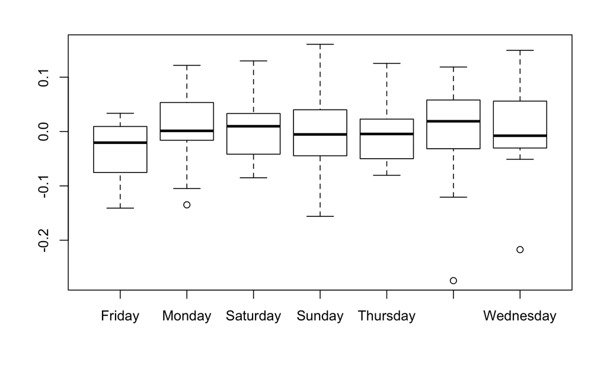

```r
# Plot the Weekday vs the Price
plot(eth.data.daily$weekday, eth.data.daily$price.detrended)
```

```r
# Regression of day vs Price
lm.fit <- lm(price.detrended ~ weekday, data=eth.data.daily)
```

The plot above shows the estimated effect of weekday on the ETH price. The pattern is a little inconsisten in this plot.

```r
summary(lm.fit)
```

```
Call:
lm(formula = price.detrended ~ weekday, data = eth.data.daily)

Residuals:
      Min        1Q    Median        3Q       Max
-0.268605 -0.037840  0.000121  0.040698  0.161714

Coefficients:
                 Estimate Std. Error t value Pr(>|t|)
(Intercept)      -0.03556    0.02299  -1.547    0.126
weekdayMonday     0.04264    0.03251   1.311    0.194
weekdaySaturday   0.04208    0.03251   1.294    0.199
weekdaySunday     0.03435    0.03251   1.056    0.294
weekdayThursday   0.03821    0.03251   1.175    0.244
weekdayTuesday    0.02981    0.03251   0.917    0.362
weekdayWednesday  0.03587    0.03251   1.103    0.273

Residual standard error: 0.07964 on 77 degrees of freedom
Multiple R-squared:  0.03101,   Adjusted R-squared:  -0.0445
F-statistic: 0.4107 on 6 and 77 DF,  p-value: 0.8698
```

The table above shows the results of the linear regression for ETH against the weekday. The summary confirms that monday and saturday have the highest effect. However there is not a strong difference to the other days.

[figure not shown]

The image above shows a similar pattern to the BTC coin price, but again there is no strong evidence of time effects.

# Summary

In summary, both linear models suggest an increase in price on the weekends. While not statistically significant to a 5% level p vaue, it would definitey be worth keeping an eye on and validating on future data.

Finally with regard to hours in the day, there appears to be a very slight trend heading into Saturday. This could be due to noise in the current sample and I would hesitate to draw strong conclusions given the current small sample size.

# Strategy backtest

Buy on Wednesday at 4pm and sell on Saturday at 4pm

```r
for (i in 1:nrow(btc.data)){
  if (btc.data[i,'weekday.hour'] == "Wednesday_16"){
    owned.coins <- money/as.numeric(as.character(btc.data[i,'Open']))
  }

  if (btc.data[i,'weekday.hour'] == "Saturday_16"){
    money <- owned.coins*as.numeric(as.character(btc.data[i,'Open']))
    print(money)
    owned.coins <- 0
  }
}
```

```
[1] 0.8923406
[1] 0.7341353
[1] 0.8135385
[1] 0.8524141
[1] 1.142134
[1] 1.114006
[1] 1.051032
[1] 1.098998
[1] 1.276712
[1] 1.169673
[1] 1.269569
[1] 1.123187
```

End with a 12% increase, compared to general BTC losses on the overall market.

```r
for (i in 1:nrow(eth.data)){
  if (eth.data[i,'weekday.hour'] == "Wednesday_16"){
    owned.coins <- money/as.numeric(as.character(eth.data[i,'Open']))
  }

  if (eth.data[i,'weekday.hour'] == "Saturday_16"){
    money <- owned.coins*as.numeric(as.character(eth.data[i,'Open']))
    print(money)
    owned.coins <- 0
  }
}
```

```
[1] 0.9168445
[1] 0.860607
[1] 0.9803597
[1] 1.005872
[1] 1.444508
[1] 1.473357
[1] 1.338724
[1] 1.407962
[1] 1.535092
[1] 1.488704
[1] 1.475478
[1] 1.382572
```

On the ETH test, the strategy would yield a 38% increase over the tested timerange. Compared to a 3% increase over the entire timerange.

```r
eth.data$Close[nrow(eth.data)]/eth.data$Close[1]
```

```
[1] 1.028718
```

In summary, this methodology performed better than the market over the given timerange of December to March.